# Better Practices for Effective Data Exploration

2025 Pre-Datathon Workshop

Dr. Weijia Jia

03/24/2025

# Example: Urbana Open Expenditure

Data Source: State of Illinois Data Portal https://data.illinois.gov/

[Urbana Open Expenditure Dataset Link](https://data.illinois.gov/Local-Government/City-Of-Urbana-Open-Expenditures-Payment-Details/p34w-i7rn/about_data)

This dataset contains payment details that are the source for the Urbana City’s Open Expenditures website. The data was last updated on March 9th, 2025, covering records from fiscal years 2013 to 2025. The dataset includes 166K rows and 25 columns.

```r
library(tidyverse)
OE <- read_csv("Urbana Open Expenditures.csv") # read_csv() from readr package
names(OE)
```

```
##  [1] "fiscal_year"                      "fiscal_year_period"
##  [3] "department"                       "division"
##  [5] "program"                          "budget_category"
##  [7] "expense_category"                 "fund"
##  [9] "fund_type"                        "vendor"
## [11] "vendor_id"                        "vendor_zip"
## [13] "payment_id"                       "payment_method"
## [15] "payment_date"                     "payment_status"
## [17] "invoice_id"                       "invoice_line_number"
## [19] "invoice_line_distribution_number" "invoice_date"
## [21] "amount"                           "description"
## [23] "contract_number"                  "purchase_order_number"
## [25] "purchase_order_line_number"
```

# Check Missing Values

### Quickly check the number of missing values in each column

```r
OE %>%
  summarize_all(~sum(is.na(.)))%>%
  print(width=Inf) ### Show all columns
```

```
## # A tibble: 1 × 25
##   fiscal_year fiscal_year_period department division program budget_category
##         <int>              <int>      <int>    <int>   <int>           <int>
## 1           0                  0        241      291    1073            3799
##   expense_category  fund fund_type vendor vendor_id vendor_zip payment_id
##              <int> <int>     <int>  <int>     <int>      <int>      <int>
## 1                0     0     65570      0      3470      68893       3470
##   payment_method payment_date payment_status invoice_id invoice_line_number
##            <int>        <int>          <int>      <int>               <int>
## 1         166441            0         100871     100871                   0
##   invoice_line_distribution_number invoice_date amount description
##                              <int>        <int>  <int>       <int>
## 1                           166441       100871      0        8402
##   contract_number purchase_order_number purchase_order_line_number
##             <int>                 <int>                      <int>
## 1               0                154941                     166441
```

### Use VIM package – The VIM package offers a number of visualizations and aggregations for pattern discovery in missing data

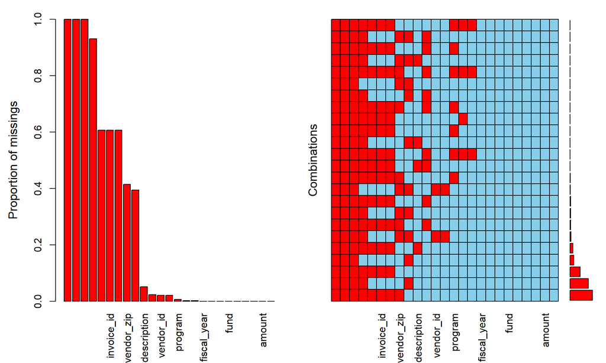

```
##
##  Variables sorted by number of missings:
##                          Variable       Count
##                    payment_method 1.000000000
##  invoice_line_distribution_number 1.000000000
##        purchase_order_line_number 1.000000000
##             purchase_order_number 0.930906447
##                    payment_status 0.606046587
##                        invoice_id 0.606046587
##                      invoice_date 0.606046587
##                        vendor_zip 0.413918446
##                         fund_type 0.393953413
##                       description 0.050480350
##                   budget_category 0.022824905
##                         vendor_id 0.020848229
##                        payment_id 0.020848229
##                           program 0.006446729
##                          division 0.001748367
##                        department 0.001447961
##                       fiscal_year 0.000000000
##                fiscal_year_period 0.000000000
##                  expense_category 0.000000000
##                              fund 0.000000000
##                            vendor 0.000000000
##                      payment_date 0.000000000
##               invoice_line_number 0.000000000
##                            amount 0.000000000
##                   contract_number 0.000000000
```

```r
VIM::aggr(OE, sortVar = TRUE)
```

Here,

- `sortVar = TRUE` – sort variables from high to low fractions of missing values.
- The *Percentage of missing values per variable plot* contains a barplot showing fractions of missing values per variable.
- In the *Occurrence of missing data patterns plot*, a value that is missing is colored red, and the observed values are colored light blue.

### Remove Columns with High Missing Values

```r
OE <- OE %>%
  select(-c(payment_method, invoice_line_distribution_number,
            purchase_order_line_number, purchase_order_number))
```

In this dataset, the numerical variable `amount` variable has no missing values. Please refer to “Additional Notes for Urbana Open Expenditure Data” for more information on linear regression-based imputation for **imputing numerical variables**.

# Better Data Visualization

```r
library(kableExtra)
# Ensure the `kableExtra` package is installed to knit this Rmd file smoothly.
```

Five guidelines for better data visualizations from Jon Schwabish’s book called [Better Data Visualizations](https://policyviz.com/pv_books/better-data-visualizations-a-guide-for-scholars-researchers-and-wonks/).

- Show the data
- Avoid the spaghetti chart
- Reduce the clutter
- Integrate the graphics and text
- Start with gray

# Data Visualization Guideline 1: Show the Data

> “Your reader can only grasp your point, argument, or story if they see the data. – Jon Schwabish”

Choose the right charts and graphs for the job:

- Visualizing Relationships: The Impact of **Scatterplots**
- Tracking Trends: The Impact of **Line Graphs**
- Comparing Multicategories: The Role of **Bar Charts**
- Exploring Data Clusters: Insights from **Histograms** and **Box Plots**
  - Histograms and box plots show where your data is clustered and can compare categories.
- Pie Charts: Enhancing Visualization Details
  - Pie charts are powerful for **adding** detail to other visualizations, but aren’t as effective on their own.
  - Bar charts are favored over pie charts.
- More R chart examples can be find at [The R Graph Gallery](https://r-graph-gallery.com/)

# Five Important Graphs Summary (Base R vs ggplot)

Base R graphics

```r
# scatterplot
  plot(x, y)

# linegraph
  plot(x, y, type="l")
  ## Add another line to the plot
  lines(x, z)

  #linegraph with dots
  plot(x, y, type="b")



# histogram
  hist(x)


# boxplot
  boxplot(y)
  boxplot(y ~ x)






# barplot of variable x
  counts=table(x)
  barplot(counts)
```

Graphics using ggplot

```r
# scatterplot
ggplot(data=df, mapping=aes(x=xvar, y=yvar)) +
  geom_point()

# linegraph
ggplot(data=df, mapping=aes(x=xvar, y=yvar)) +
  geom_line()

  #linegraph with dots
  ggplot(data=df, mapping=aes(x=xvar, y=yvar)) +
    geom_line() +
    geom_point()

# histogram
ggplot(data=df, mapping=aes(x=xvar)) +
  geom_histogram()

# boxplot
  # boxplot of one variable yvar
  ggplot(data=df, mapping=aes(y=yvar)) +
    geom_boxplot()
  # boxplot of the yvar vs xvar
  ggplot(data=df, mapping=aes(x=xvar, y=yvar)) +
    geom_boxplot()


# barplot of variable x
  # If not pre-counted, use geom_bar()
  ggplot(data=df, mapping=aes(x=xvar))+
   geom_bar()
  # If precounted, use geom_col()
  ggplot(data=df_counted, mapping=aes(x=xvar,y=counts))+
    geom_col()
```

# Data Visualization Guideline 1 Continue

Urbana Open Expenditure – Total Expenditure by Date and Department

Step 1: Convert the `payment_date` column to a date-time object, then extract and retain only the date (dropping the time component).

Step 2: Sum the `amount` by `payment_date` and `department` to calculate `daysum`.

```r
library(lubridate)

OE <- OE %>% mutate(payment_date = as.Date(mdy_hms(payment_date)))

OE_daysum <- OE %>%
  group_by(payment_date, department) %>%
  summarize(daysum = sum(amount)) # Daily total expenditure
```

Step 3: Draw the line chart. Use `labs()` to add the x-label, y-label, and title.

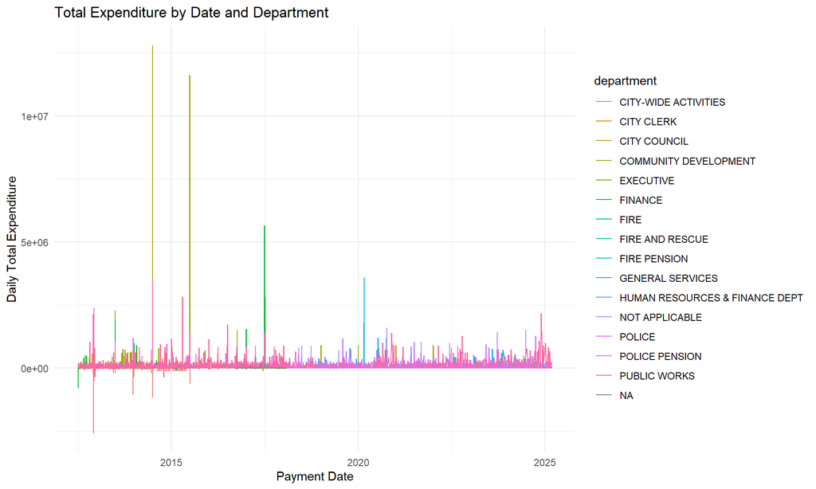

```r
OE_daysum %>%
  ggplot(aes(x = payment_date, y = daysum, color = department)) +
  geom_line() +
  labs(x="Payment Date",
       y="Daily Total Expenditure",
       title = "Total Expenditure by Date and Department")+
  theme_minimal()
```

# Data Visualization Guideline 1 Continue – remove outliers using IQR rule

The plot above shows some negative expenditures, likely resulting from refunds, reimbursements, corrections, or similar adjustments. Moreover, we observe some unusually large values.

**From now on, we only consider the positive expenditures.**

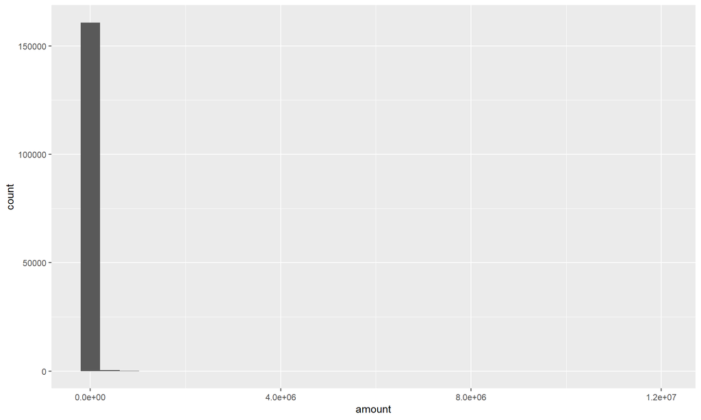

```r
OE <- OE %>%
  filter(amount > 0)

OE %>% ggplot(aes(x=amount)) + geom_histogram() # Extremely right-skewed
```

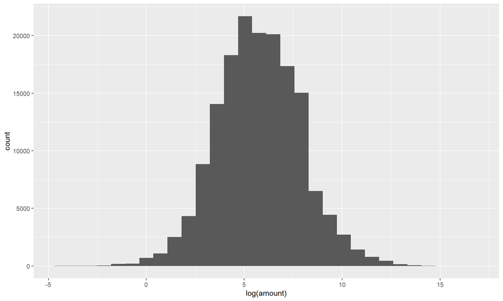

```r
OE %>% ggplot(aes(x = log(amount))) + geom_histogram() # roughly symmetric
```

Transform the data using the natural logarithm to reduce skewness. Then use an IQR-based outlier detection method.We may adjusting the multiplier, i.e. use a larger multiplier (e.g., 2.5 or 3) instead of the common multiplier 1.5 for more conservative filtering.

```r
OE <- OE %>%
  mutate(logamount = log(amount),
         Q1 = quantile(logamount, 0.25),
         Q3 = quantile(logamount, 0.75),
         IQR = Q3 - Q1,
         lower_threshold = Q1 - 2.5 * IQR,
         upper_threshold = Q3 + 2.5 * IQR) %>%
  # We apply large multiplier 2.5 here, instead of 1.5
  filter(logamount < upper_threshold & logamount > lower_threshold) %>%
  # Remove outliers using the IQR rule
  select(-c(logamount, Q1, Q3, IQR, lower_threshold, upper_threshold))
  # remove the newly created variables from the data frame
```

- We regenerate the previous visualization after excluding outliers.

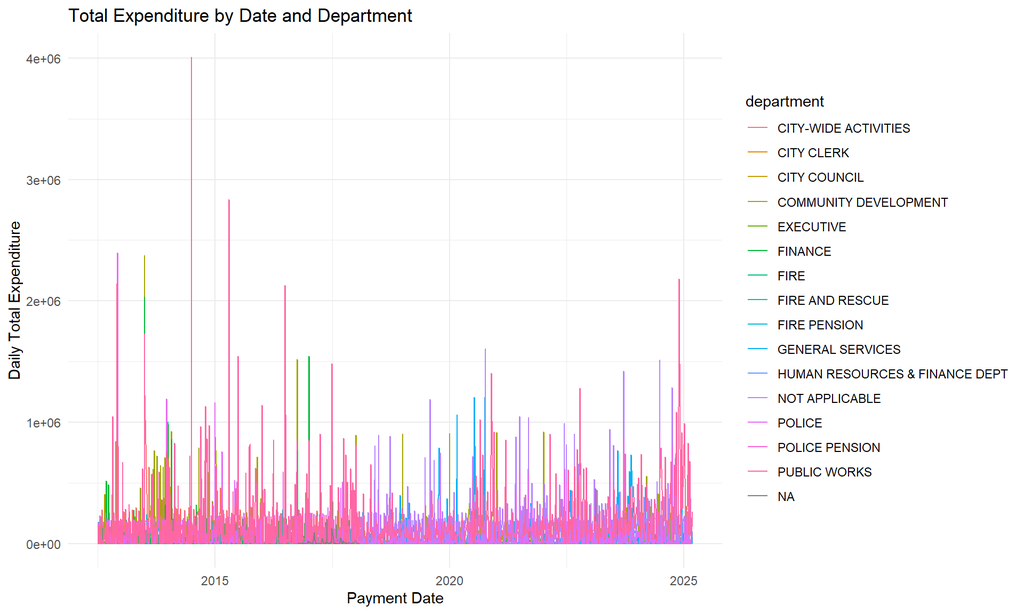

```r
OE_daysum <- OE %>%
  group_by(payment_date, department) %>%
  summarize(daysum = sum(amount), .groups = "drop") # Daily total expenditure

OE_daysum %>%
  ggplot(aes(x = payment_date, y = daysum, color = department)) +
  geom_line() +
  labs(x="Payment Date",
       y="Daily Total Expenditure",
       title = "Total Expenditure by Date and Department")+
  theme_minimal()
```

# Data Visualization Guideline 2: Avoid the Spaghetti Chart

> “Sometimes we face the challenge of including lots of data in a single graph but we don’t need to try to pack everything into a single graph.

Faceting or using small multiples is a useful way to de-clutter a busy data visualization. Faceting is a very natural method in ggplot2. With effective small multiples, if a reader understand how to read one small multiple then they should understand how to read all of the multiples. Two tips:

1. Arrange the small multiples in a logical order
2. Use the same layout, size, font, and color in each small multiple

We modify the line chart from the previous section

```r
p1 <- # the previous plot
  OE_daysum %>%
  ggplot(aes(x = payment_date, y = daysum, color = department)) +
  geom_line() +
  labs(x="Payment Date",
       y="Daily Total Expenditure")+
  theme_minimal()+
  labs(title = "Without facet_wrap()")

OE_daysum %>%
  group_by(department) %>%
  summarise(sum=sum(daysum)) %>%
  arrange(desc(sum)) %>%
  head(7)
```

```
## # A tibble: 7 × 2
##   department                   sum
##   <chr>                      <dbl>
## 1 PUBLIC WORKS          176350245.
## 2 NOT APPLICABLE        101240028.
## 3 COMMUNITY DEVELOPMENT  84771247.
## 4 POLICE                 74952680.
## 5 FIRE AND RESCUE        42718122.
## 6 FINANCE                41125517.
## 7 GENERAL SERVICES       24745632.
```

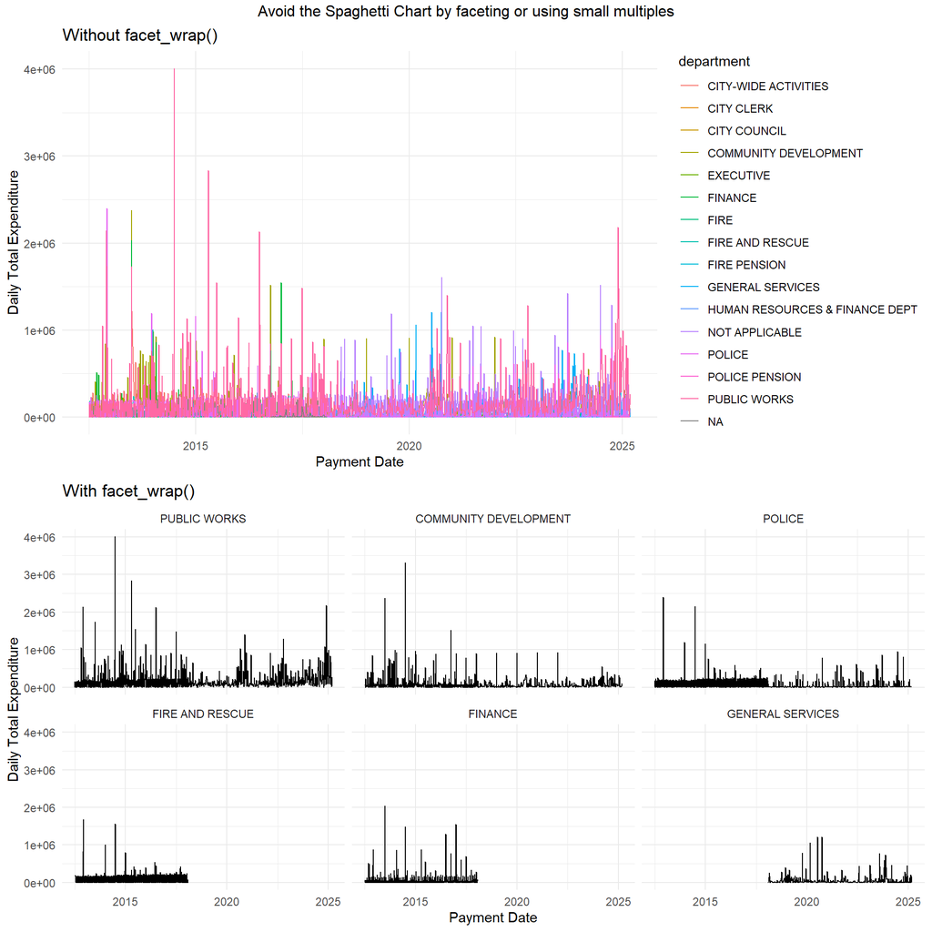

```r
p2 <- OE_daysum %>%
  filter(department %in% c("PUBLIC WORKS", "COMMUNITY DEVELOPMENT", "POLICE",
                           "FIRE AND RESCUE", "FINANCE", "GENERAL SERVICES"
                           )) %>%
  mutate(department = factor(department,
         levels = c("PUBLIC WORKS", "COMMUNITY DEVELOPMENT", "POLICE",
                  "FIRE AND RESCUE", "FINANCE", "GENERAL SERVICES") #save order
                      )) %>%
  ggplot(aes(x = payment_date, y = daysum)) +
  geom_line() +
  labs(x="Payment Date",
       y="Daily Total Expenditure")+
  theme_minimal()+
  facet_wrap(~department)+
  labs(title = "With facet_wrap()")

library(grid)
library(gridExtra)
grid.arrange(p1, p2, nrow=2,
             top=textGrob("Avoid the Spaghetti Chart by faceting or using small multiples"))
```